# F1 Prediction

# FORMULA 1 CHAMPIONSHIP EDA AND WINNER PREDICTION

## Loading libraries

```r
library(ggplot2)
library(dplyr)
library(rpart)
library(corrplot)
library(treemap)
library(treemapify)
library(tree)
library(randomForest)
library(caret)
library(e1071)
library(rpart.plot)
library(car)
```

## Data loading

```r
df = read.csv("~/Documents/GitHub/F1_prediction/datasets/df.csv")
str(df)
```

```
## 'data.frame':    23693 obs. of  25 variables:
##  $ raceId          : int  1 1 1 1 1 1 1 1 1 1 ...
##  $ driverId        : int  10 15 16 17 18 2 20 21 22 3 ...
##  $ constructorId   : int  7 7 10 9 23 2 9 10 23 3 ...
##  $ circuitId       : int  1 1 1 1 1 1 1 1 1 1 ...
##  $ resultId        : int  7557 7556 7562 7565 7554 7563 7566 7564 7555 7559 ...
##  $ number          : int  10 9 20 14 22 6 15 21 23 16 ...
##  $ grid            : int  19 20 16 8 1 9 3 15 2 5 ...
##  $ positionOrder   : int  4 3 9 12 1 10 13 11 2 6 ...
##  $ points          : num  5 6 0 0 10 0 0 0 8 3 ...
##  $ laps            : int  58 58 58 57 58 58 56 58 58 58 ...
##  $ fastestLapSpeed : num  216 215 215 216 217 ...
##  $ status          : chr  "Finished" "Finished" "Finished" "+1 Lap" ...
##  $ dob             : chr  "1982-03-18" "1974-07-13" "1983-01-11" "1976-08-27" ...
##  $ driv_nationality: chr  "German" "Italian" "German" "Australian" ...
##  $ fullname        : chr  "Timo Glock" "Jarno Trulli" "Adrian Sutil" "Mark Webber" ...
##  $ round           : int  1 1 1 1 1 1 1 1 1 1 ...
##  $ date            : chr  "2009-03-29" "2009-03-29" "2009-03-29" "2009-03-29" ...
##  $ const_name      : chr  "Toyota" "Toyota" "Force India" "Red Bull" ...
##  $ name            : chr  "Albert Park Grand Prix Circuit" "Albert Park Grand Prix Circuit" "Albert Park Grand Prix Circuit" "Albert Park Grand Prix Circuit" ...
##  $ const_points    : num  11 11 0 0 18 0 0 0 18 3 ...
##  $ const_wins      : int  0 0 0 0 1 0 0 0 1 0 ...
##  $ driver_age      : int  27 35 26 33 29 32 22 36 37 24 ...
##  $ fastestLap_ms   : num  88416 88916 88943 88508 88020 ...
##  $ winner          : int  0 0 0 0 1 0 0 0 0 0 ...
##  $ wins            : int  1 1 1 1 2 1 1 1 1 1 ...
```

```r
head(df)
```

```
##   raceId driverId constructorId circuitId resultId number grid positionOrder
## 1      1       10             7         1     7557     10   19             4
## 2      1       15             7         1     7556      9   20             3
## 3      1       16            10         1     7562     20   16             9
## 4      1       17             9         1     7565     14    8            12
## 5      1       18            23         1     7554     22    1             1
## 6      1        2             2         1     7563      6    9            10
##   points laps fastestLapSpeed   status        dob driv_nationality
## 1      5   58         215.920 Finished 1982-03-18           German
## 2      6   58         214.706 Finished 1974-07-13          Italian
## 3      0   58         214.640 Finished 1983-01-11           German
## 4      0   57         215.695   +1 Lap 1976-08-27       Australian
## 5     10   58         216.891 Finished 1980-01-19          British
## 6      0   58         216.245 Finished 1977-05-10           German
##        fullname round       date  const_name                           name
## 1    Timo Glock     1 2009-03-29      Toyota Albert Park Grand Prix Circuit
## 2  Jarno Trulli     1 2009-03-29      Toyota Albert Park Grand Prix Circuit
## 3  Adrian Sutil     1 2009-03-29 Force India Albert Park Grand Prix Circuit
## 4   Mark Webber     1 2009-03-29    Red Bull Albert Park Grand Prix Circuit
## 5 Jenson Button     1 2009-03-29       Brawn Albert Park Grand Prix Circuit
## 6 Nick Heidfeld     1 2009-03-29  BMW Sauber Albert Park Grand Prix Circuit
##   const_points const_wins driver_age fastestLap_ms winner wins
## 1           11          0         27         88416      0    1
## 2           11          0         35         88916      0    1
## 3            0          0         26         88943      0    1
## 4            0          0         33         88508      0    1
## 5           18          1         29         88020      1    2
## 6            0          0         32         88283      0    1
```

Our starting data frame is composed by 25 columns of features that define for each row a Driver performance in a specific Race of a specific year. So for each row:

- 5 columns describe the unique observation: raceId, driverId, constructorId, circuitId, resultId. They were useful in the initial part of the data processing to merge multiple features from other datasets into this one main data frame that include all the features that we later use for data analysis and prediction.
- 2 columns define the performance of the driver in the specific race, mainly ‘positionOrder’ and the binary ‘winner’. These are the target variables that we used for the regression and classification tasks.
- 11 columns are numerical features used:
  - number, number of each driver’s car
  - grid, starting position for the driver
  - points, number of points earned in the race
  - laps, number of laps in the race
  - fastestLapSpeed
  - round, number of the Race in the season
  - const_points, number of points earned by the team before this race
  - const_wins, number of wins of the team before the race
  - driver_age, age of each driver
  - fastestLap_ms, fastest lap in the qualification race
  - wins, number of wins before the race for the driver
- 5 columns that describe categorical features:
  - status, what happened in the race for the driver
  - driv_nationality
  - fullname, name of the driver
  - const_name, name of the team
  - name, name of the circuit in which the race takes place
- 2 columns for dates: ‘dob’ is birth date for each driver, ‘date’ is the date of the Race.

# EDA and plots.

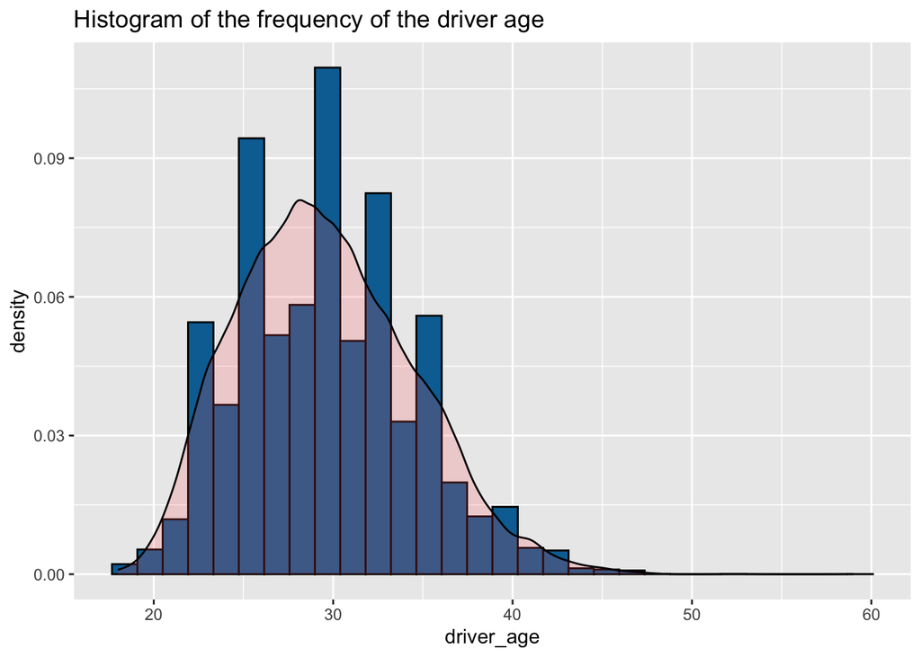

```r
ggplot(df, aes(x=driver_age)) +
 geom_histogram(aes(y=after_stat(density)), colour="black", fill= '#076fa2')+
 geom_density(alpha=.2, fill="#FF6666") +
 labs(title = 'Histogram of the frequency of the driver age')
```

The frequency of the drivers’ age from 1950 to 2022 can be traced to a normal distribution, with a peak around 30 years old. Since the column driver_age from the data frame collects also the various age during which the drivers have raced, we can interpret this histogram also like an indicator of the retirement age of a pilot: we have a peak around 30 years old and then as the age increase its frequency decrease, so we have less and less pilot with an higher age.

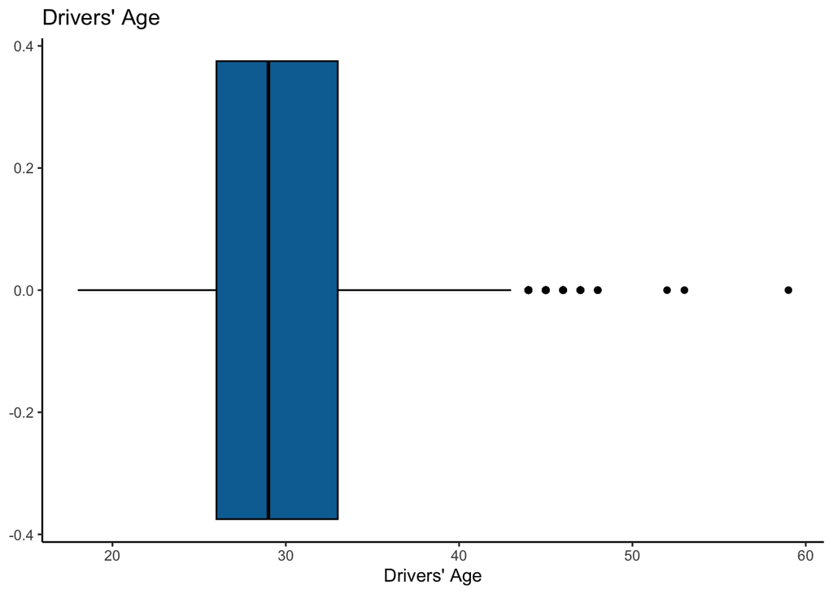

```r
ggplot(df, aes(x=driver_age)) +
  geom_boxplot(fill='#076fa2', color="black")+
  theme_classic() +
  labs(title = "Drivers' Age", x = "Drivers' Age")
```

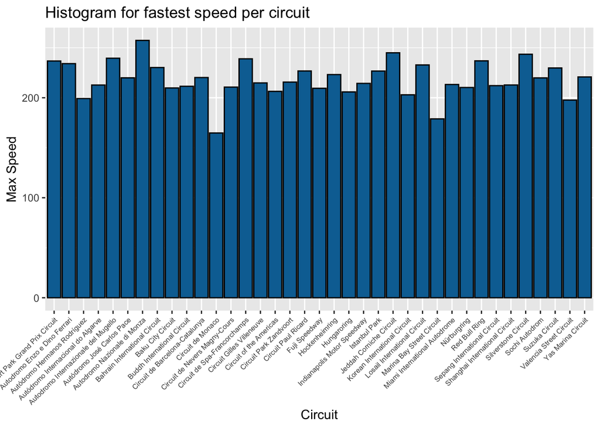

```r
df_speed <- read.csv('~/Documents/GitHub/F1_prediction/datasets/df_speed.csv')
ggplot(df_speed, aes(x=Circuit, y=Max_Speed)) +
 geom_bar(colour="black", fill= '#076fa2', stat = 'identity')+
 labs(title = 'Histogram for fastest speed per circuit', x = 'Circuit', y = 'Max Speed') +
 theme(axis.text.x = element_text(angle = 45, vjust = 1, hjust = 1, size = 6))
```

This bar plot shows the fastest lap speed for every circuit (where it has been registered, since sometimes there isn’t a max speed for a circuits, especially the oldest). From here we can see where a driver can dare the most with the accelerator.

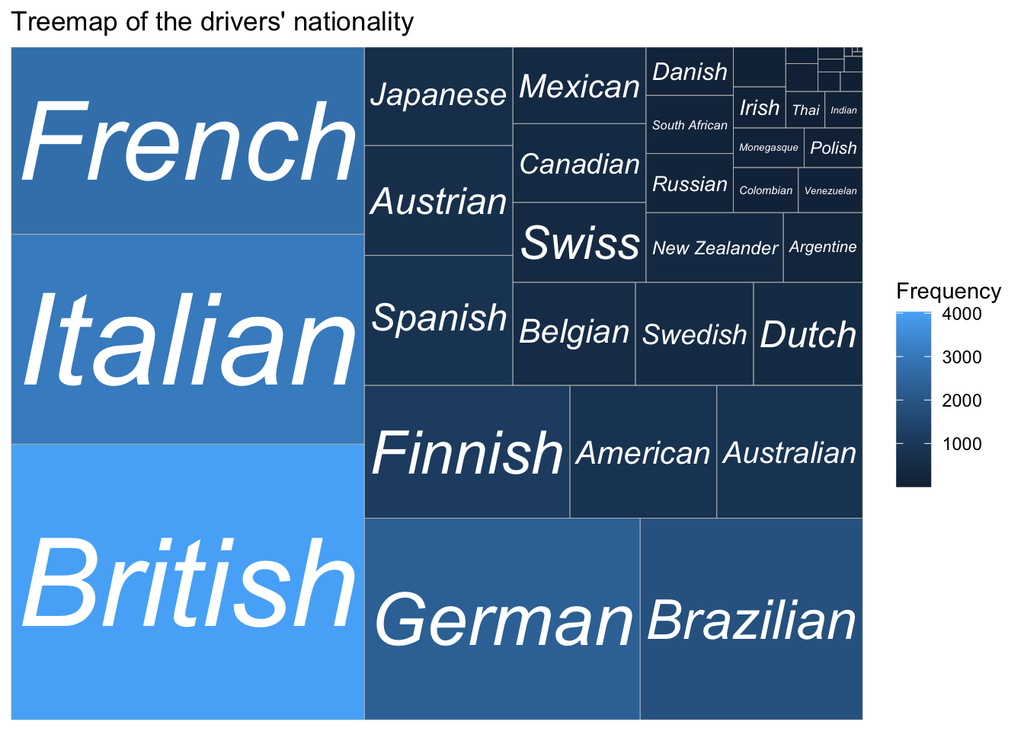

```r
nationality = data.frame(table(df$driv_nationality))
nationality$Var1 = as.character(nationality$Var1)
ggplot(nationality, aes(area = Freq, fill = Freq, label = Var1)) +
  geom_treemap() +
  geom_treemap_text(fontface = "italic", colour = "white", place = "centre", grow = TRUE) +
  labs(title = "Treemap of the drivers' nationality", fill = "Frequency")
```

With this tree map it is shown the frequency of the different nationality of the drivers over the years. The most popular is British.

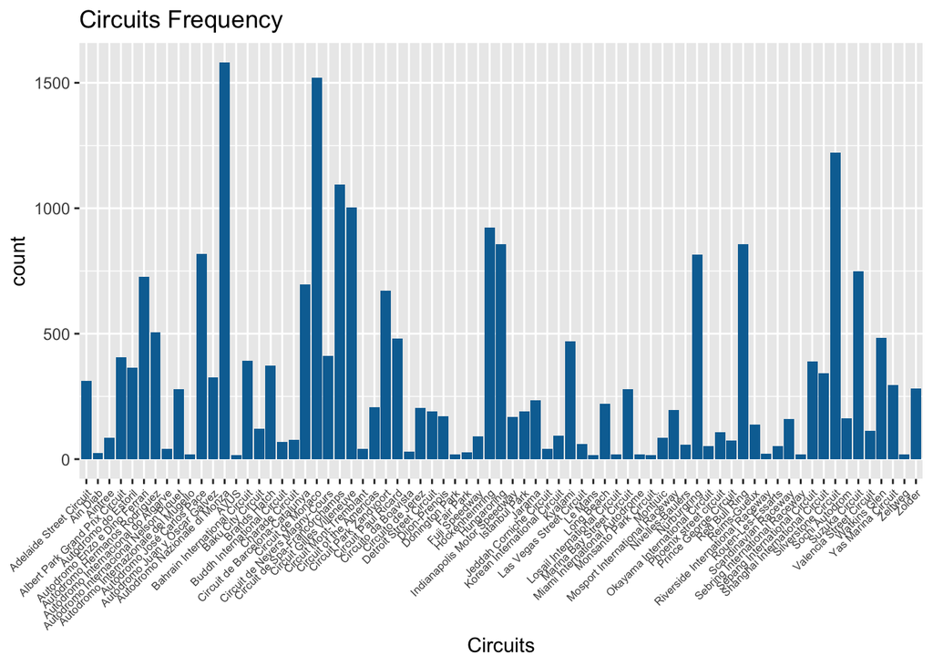

```r
ggplot(df, aes(name)) +
  labs(x = 'Circuits') +
  ggtitle('Circuits Frequency') +
  geom_bar(fill="#076fa2", position = position_dodge(0.7)) +
  theme(axis.text.x = element_text(angle = 45, vjust = 1, hjust = 1, size = 6))
```

This histogram shows the frequency of every circuit over time

Number of collisions per circuit.

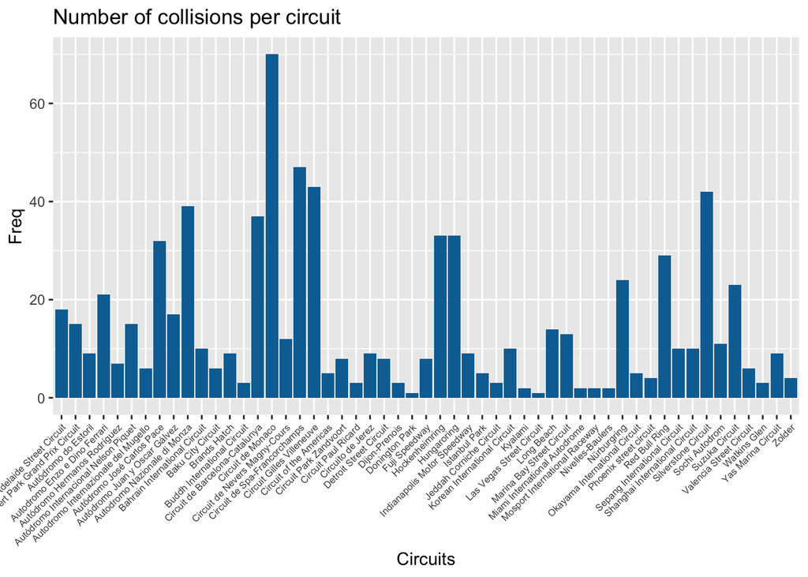

```r
#barplot showing number of collisions for each circuit
n_collision <- table(df[df$status == 'Collision', 'name'])
n_collision <- as.data.frame(n_collision)

ggplot(n_collision, aes(x = Var1, y = Freq)) +
  labs(x = 'Circuits') +
  ggtitle('Number of collisions per circuit') +
  geom_bar(fill="#076fa2", position = position_dodge(0.7), stat = 'identity') +
  theme(axis.text.x = element_text(angle = 45, vjust = 1, hjust = 1, size = 6))
```

Accident ratio per circuit.

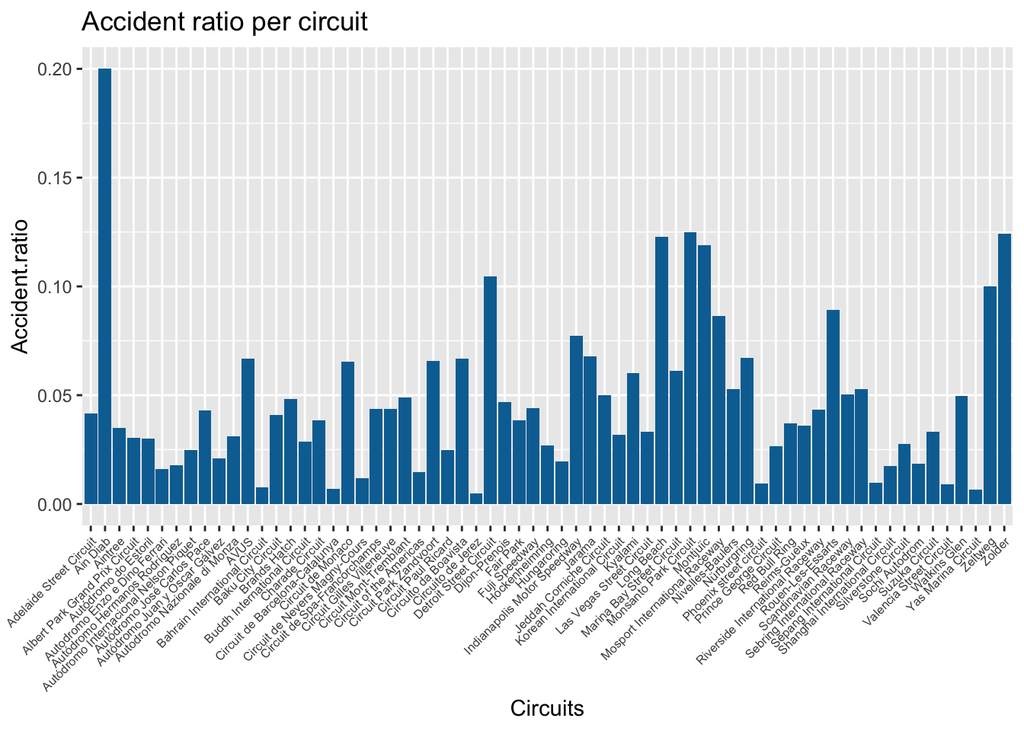

```r
n_accident = read.csv("~/Documents/GitHub/F1_prediction/datasets/n_accident.csv")
ggplot(n_accident, aes(x = as.character(Accident.Names), y = Accident.ratio)) +
  labs(x = 'Circuits') +
  ggtitle('Accident ratio per circuit') +
  geom_bar(fill="#076fa2", position = position_dodge(0.7), stat = 'identity') +
  theme(axis.text.x = element_text(angle = 45, vjust = 1, hjust = 1, size = 6))
```

Winning driver age overtime

```r
df_points = read.csv("~/Documents/GitHub/F1_prediction/datasets/df_points.csv")
```

```r
winner_Age = function(){
  df_year_winner = matrix(nrow = 1, ncol=5)
  years = seq(1958, 2022, 1)
  for (y in years){
    df_year = df_points[df_points$year == y, c(2,4,9,10)]
    id_winner = df_year[which.max(df_year$points), ]
    df_year_winner <- rbind(df_year_winner, c(y, id_winner$driverId, id_winner$points, id_winner$fullname, id_winner$driver_age))

  }
  df_year_winner = data.frame(df_year_winner)
  df_year_winner = df_year_winner[-1,]
  return(df_year_winner)
}
df_year_winner = winner_Age()
names(df_year_winner) = c('year', 'driverId', 'final_points', 'fullname', 'age')
df_year_winner$age = as.numeric(df_year_winner$age)
head(df_year_winner)
```

```
##   year driverId final_points      fullname age
## 2 1958      578           42 Mike Hawthorn  29
## 3 1959      356           31  Jack Brabham  33
## 4 1960      356           43  Jack Brabham  34
## 5 1961      403           34     Phil Hill  34
## 6 1962      289           42   Graham Hill  33
## 7 1963      373           54     Jim Clark  27
```

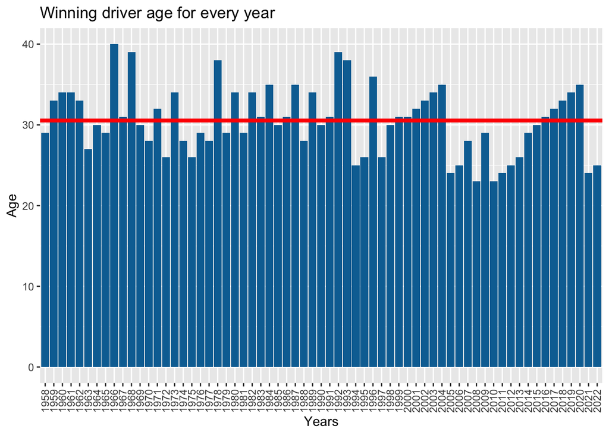

```r
#plot for winner's age over time
ggplot(df_year_winner, aes(x = year, y = age)) +
  labs(x = 'Years', y = 'Age') +
  ggtitle('Winning driver age for every year') +
  geom_bar(stat = "identity") +
  geom_col(fill = "#076fa2") +
  theme(axis.text.x = element_text(angle = 90, vjust=0.5, hjust = 1)) +
  geom_abline(slope = 0, intercept = mean(df_year_winner$age), color = 'red', linewidth = 1.5)
```

How important is the pole position in each circuit to win the race? Each column is the ratio between how many times a driver have won a race after he has qualified first.

```r
pole_ratio = read.csv("~/Documents/GitHub/F1_prediction/datasets/pole_ratio.csv")
```

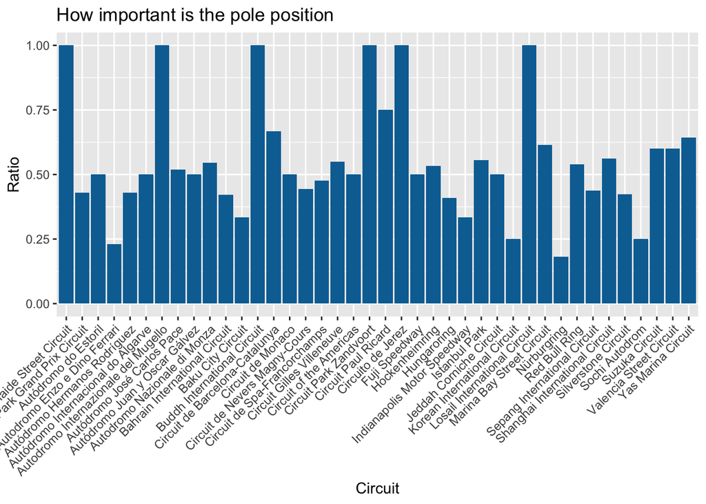

```r
ggplot(pole_ratio, aes(x = X1, y = X2)) +
  labs(x = 'Circuit', y = 'Ratio') +
  ggtitle('How important is the pole position') +
  geom_bar(stat = "identity") +
  geom_col(fill = "#076fa2") +
  theme(axis.text.x = element_text(angle = 45, hjust = 1))
```

Correlation

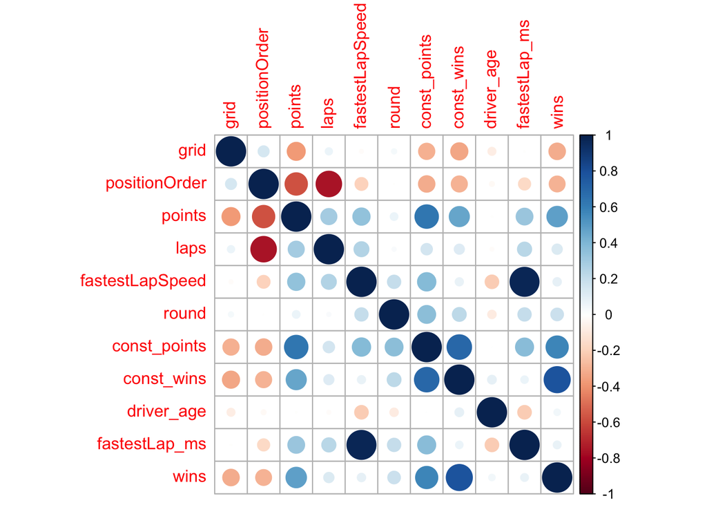

```r
#CORRELATION MATRIX for numerical features
corr_matrix = cor(df[c(7,8,9,10,11,16,20,21,22,23,25)])
corrplot(corr_matrix)
```

# DEFINING AND TRAINING ML MODELS FOR PREDICTION.

```r
df$winner = as.factor(df$winner) #converting the column to a factor.
```

Defining TRAIN and TEST dataframes.

```r
races_list = unique(df$raceId)
races_train_idx = sample(length(races_list), length(races_list)*0.8)

races_train_list = races_list[races_train_idx]
races_test_list = races_list[-races_train_idx]

#creating train & test dataframes
df.train = df[df$raceId %in% races_train_list, ]
df.test = df[df$raceId %in% races_test_list, ]
```

Fixing data.train and data.test for categorical features.

```r
#converting TRAIN and TEST categorical features in factors
df.train$status = as.factor(df.train$status)
df.train$driv_nationality = as.factor(df.train$driv_nationality)
df.train$fullname = as.factor(df.train$fullname)
df.train$const_name = as.factor(df.train$const_name)
df.train$name = as.factor(df.train$name)
str(df.train)
```

```
## 'data.frame':    18801 obs. of  25 variables:
##  $ raceId          : int  1 1 1 1 1 1 1 1 1 1 ...
##  $ driverId        : int  10 15 16 17 18 2 20 21 22 3 ...
##  $ constructorId   : int  7 7 10 9 23 2 9 10 23 3 ...
##  $ circuitId       : int  1 1 1 1 1 1 1 1 1 1 ...
##  $ resultId        : int  7557 7556 7562 7565 7554 7563 7566 7564 7555 7559 ...
##  $ number          : int  10 9 20 14 22 6 15 21 23 16 ...
##  $ grid            : int  19 20 16 8 1 9 3 15 2 5 ...
##  $ positionOrder   : int  4 3 9 12 1 10 13 11 2 6 ...
##  $ points          : num  5 6 0 0 10 0 0 0 8 3 ...
##  $ laps            : int  58 58 58 57 58 58 56 58 58 58 ...
##  $ fastestLapSpeed : num  216 215 215 216 217 ...
##  $ status          : Factor w/ 128 levels "+1 Lap","+10 Laps",..: 64 64 64 1 64 64 39 64 64 64 ...
##  $ dob             : chr  "1982-03-18" "1974-07-13" "1983-01-11" "1976-08-27" ...
##  $ driv_nationality: Factor w/ 40 levels "American","American-Italian",..: 19 24 19 5 9 19 19 24 8 19 ...
##  $ fullname        : Factor w/ 578 levels "Adrián Campos",..: 539 258 2 357 270 401 510 187 503 403 ...
##  $ round           : int  1 1 1 1 1 1 1 1 1 1 ...
##  $ date            : chr  "2009-03-29" "2009-03-29" "2009-03-29" "2009-03-29" ...
##  $ const_name      : Factor w/ 156 levels "AGS","Alfa Romeo",..: 149 149 57 125 22 14 125 57 22 154 ...
##  $ name            : Factor w/ 71 levels "Adelaide Street Circuit",..: 4 4 4 4 4 4 4 4 4 4 ...
##  $ const_points    : num  11 11 0 0 18 0 0 0 18 3 ...
##  $ const_wins      : int  0 0 0 0 1 0 0 0 1 0 ...
##  $ driver_age      : int  27 35 26 33 29 32 22 36 37 24 ...
##  $ fastestLap_ms   : num  88416 88916 88943 88508 88020 ...
##  $ winner          : Factor w/ 2 levels "0","1": 1 1 1 1 2 1 1 1 1 1 ...
##  $ wins            : int  1 1 1 1 2 1 1 1 1 1 ...
```

```r
df.test$status = as.factor(df.test$status)
df.test$driv_nationality = as.factor(df.test$driv_nationality)
df.test$fullname = as.factor(df.test$fullname)
df.test$const_name = as.factor(df.test$const_name)
df.test$name = as.factor(df.test$name)
str(df.test)
```

```
## 'data.frame':    4892 obs. of  25 variables:
##  $ raceId          : int  1000 1000 1000 1000 1000 1000 1000 1000 1000 1000 ...
##  $ driverId        : int  1 154 20 4 8 807 815 817 822 825 ...
##  $ constructorId   : int  131 210 6 1 6 4 10 9 131 210 ...
##  $ circuitId       : int  11 11 11 11 11 11 11 11 11 11 ...
##  $ resultId        : int  24003 24012 24004 24010 24005 24014 24016 24006 24007 24009 ...
##  $ number          : int  44 8 5 14 7 27 11 3 77 20 ...
##  $ grid            : int  1 10 4 11 3 13 19 12 2 9 ...
##  $ positionOrder   : int  1 10 2 8 3 12 14 4 5 7 ...
##  $ points          : num  25 1 18 4 15 0 0 12 10 6 ...
##  $ laps            : int  70 69 70 69 70 69 69 70 70 69 ...
##  $ fastestLapSpeed : num  194 191 197 192 196 ...
##  $ status          : Factor w/ 92 levels "+1 Lap","+10 Laps",..: 42 1 42 1 42 1 1 42 42 1 ...
##  $ dob             : chr  "1985-01-07" "1986-04-17" "1987-07-03" "1981-07-29" ...
##  $ driv_nationality: Factor w/ 38 levels "American","Argentine",..: 7 16 17 33 15 17 26 3 15 13 ...
##  $ fullname        : Factor w/ 437 levels "Adrián Campos",..: 249 370 381 117 242 298 385 79 422 241 ...
##  $ round           : int  12 12 12 12 12 12 12 12 12 12 ...
##  $ date            : chr  "2018-07-29" "2018-07-29" "2018-07-29" "2018-07-29" ...
##  $ const_name      : Factor w/ 126 levels "AGS","Alfa Romeo",..: 82 48 41 79 41 97 45 96 82 48 ...
##  $ name            : Factor w/ 49 levels "Adelaide Street Circuit",..: 27 27 27 27 27 27 27 27 27 27 ...
##  $ const_points    : num  345 66 335 52 335 82 59 223 345 66 ...
##  $ const_wins      : int  5 0 4 0 4 0 0 3 5 0 ...
##  $ driver_age      : int  33 32 31 37 39 31 28 29 29 26 ...
##  $ fastestLap_ms   : num  81107 82606 80056 82090 80292 ...
##  $ winner          : Factor w/ 2 levels "0","1": 2 1 1 1 1 1 1 1 1 1 ...
##  $ wins            : int  6 1 5 1 1 1 1 3 1 1 ...
```

Fixing FACTOR LEVELS in the testing data frame In this way we set factor levels of ALL categorical columns of df.test to be exactly the same as df.train. Otherwise, we would encounter problem in the classifications method when predicting the new data from df.test using the model trained on df.train.

```r
levels(df.test$status) <- levels(df.train$status)
levels(df.test$driv_nationality) <- levels(df.train$driv_nationality)
levels(df.test$fullname) <- levels(df.train$fullname)
levels(df.test$const_name) <- levels(df.train$const_name)
levels(df.test$name) <- levels(df.train$name)
```

### SCORING FUNCTIONS

The two scoring functions we created, simply calculate the accuracy of the prediction of the winner of each race.

For the regressions, the scoring functions sort the prediction of positionOrder for each race (by using raceId) and take the smallest value of the prediction. If the same driver (a row of df.test) has the real value of positionOrder equal to 1, then the prediction is correct and the score is increased by 1. After scrolling through all races that are present in df.test, the accuracy_score is defined as the ratio between score and the number of races.

For the classification, the scoring function works similarly but there is a difference. We are using the classifications models to predict winner defined in {0,1} but the models in action are going to assign 1 to multiple drivers in the same race (but we can have just one winner in a race). So instead we look for the greatest probability among the driver of a race to have the winner feature equal to 1. The driver with the greatest probability of having the winner feature equal to 1 would be the driver with the greatest probability of winning the race and hence he is the winner our function pick. The definition of score works in the same way as in the scoring function for regressions.

Defining scoring function for Regression.

```r
score_regression <- function(test, prediction){

  df.score.regres = data.frame(test, prediction)
  colnames(df.score.regres)[c(26)] = c('prediction') #substitute with 25

  racelist = unique(df.score.regres$raceId)

  score = 0
  for (i in 1:length(racelist)){
    race = df.score.regres[df.score.regres$raceId %in% racelist[i], ]
    pred_winner_idx = which.min(race$prediction)
    if (race$positionOrder[pred_winner_idx] == 1){
      score = score + 1
    }
  }

  score_ratio = score/length(racelist)
  return(score_ratio)
}
```

Defining scoring function for Classification.

```r
score_classification <- function(test, prediction){

  df.score.class = data.frame(test, prediction)
  colnames(df.score.class)[c(26,27)] = c('pred_0', 'pred_1')

  racelist = unique(df.score.class$raceId)

  score = 0
  for (i in 1:length(racelist)){
    race = df.score.class[df.score.class$raceId %in% racelist[i], ]
    pred_winner_idx = which.max(race$pred_1)
    if (race$positionOrder[pred_winner_idx] == 1){
      score = score + 1
    }
  }

  score_ratio = score/length(racelist)
  return(score_ratio)
}
```

### REGRESSION

#### Training and testing linear regression models.

For the regression model we decided to use as explanatory variables most of the numerical features as: grid, laps, fastestLapSpeed, round, const_points, const_wins, fastestLap_ms and wins that presumably would help predict and explain the final position of the driver. Some variables were excluced as points, since its high correlation with the final position (higher number of points means a higher position, were 1 is the highest position).

```r
#first, we train and test a linear model with all numerical features in the dataset.
#linear regression
linearmodel = lm(positionOrder ~ grid + laps + fastestLapSpeed + round + const_points + const_wins + fastestLap_ms + wins, data = df.train)
summary(linearmodel)
```

```
##
## Call:
## lm(formula = positionOrder ~ grid + laps + fastestLapSpeed +
##     round + const_points + const_wins + fastestLap_ms + wins,
##     data = df.train)
##
## Residuals:
##      Min       1Q   Median       3Q      Max
## -19.8829  -2.9957  -0.0226   2.9440  20.3343
##
## Coefficients:
##                   Estimate Std. Error  t value Pr(>|t|)
## (Intercept)      2.112e+01  1.125e-01  187.620  < 2e-16 ***
## grid             1.106e-01  5.199e-03   21.274  < 2e-16 ***
## laps            -2.175e-01  1.377e-03 -157.943  < 2e-16 ***
## fastestLapSpeed  9.695e-03  1.617e-03    5.995 2.07e-09 ***
## round            1.266e-01  7.399e-03   17.114  < 2e-16 ***
## const_points    -1.463e-02  6.819e-04  -21.452  < 2e-16 ***
## const_wins      -1.449e-01  3.368e-02   -4.301 1.71e-05 ***
## fastestLap_ms   -1.214e-05  3.579e-06   -3.391 0.000698 ***
## wins            -4.642e-01  4.772e-02   -9.728  < 2e-16 ***
## ---
## Signif. codes:  0 '***' 0.001 '**' 0.01 '*' 0.05 '.' 0.1 ' ' 1
##
## Residual standard error: 4.609 on 18792 degrees of freedom
## Multiple R-squared:  0.6345, Adjusted R-squared:  0.6343
## F-statistic:  4077 on 8 and 18792 DF,  p-value: < 2.2e-16
```

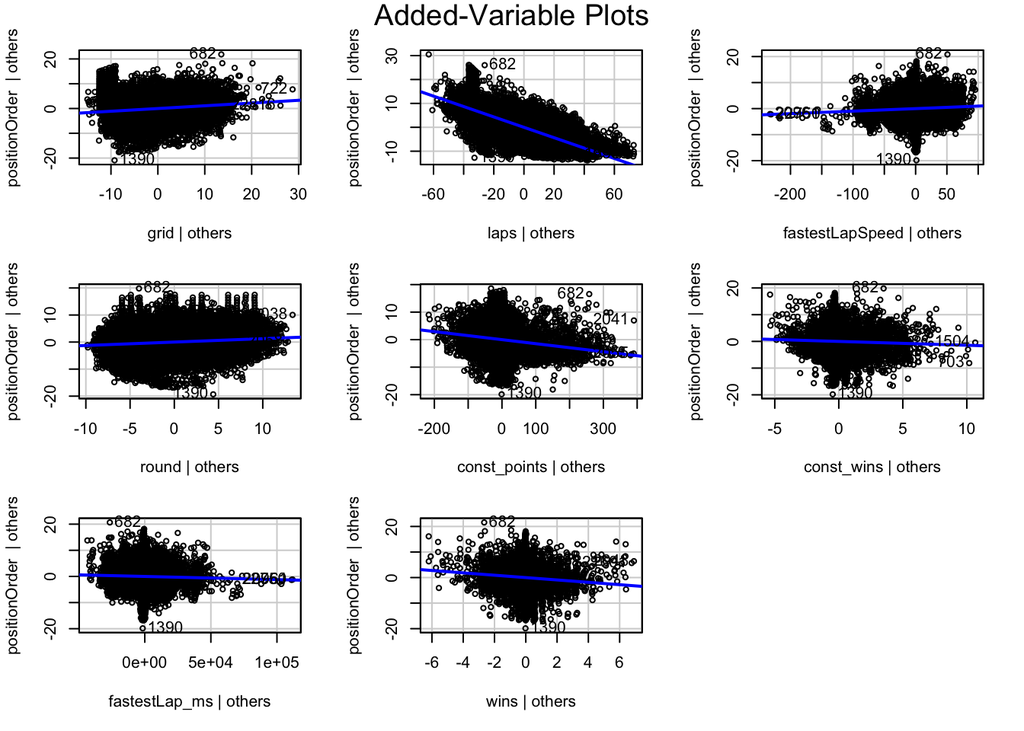

```r
avPlots(linearmodel)
```

```r
predict_lm = predict(linearmodel, df.test)
score_regression(df.test, predict_lm)
```

```
## [1] 0.6650246
```

#### Regression tree

```r
predict_rt = predict(tree(positionOrder ~ grid + number + laps + fastestLapSpeed + round + const_points + const_wins + driver_age + fastestLap_ms + wins, df.train), newdata = df.test)
score_regression(df.test, predict_rt) #47%
```

```
## [1] 0.453202
```

### CLASSIFICATION

In this type of prediction we are using the features class ‘winner’ that we have created. We want to predict the probability of class=1 (winner) or class=0 (not winner). Then we are going to sort the probabilities and pick the greater probability of class=1, hence the driver with the greatest probability of being a winner.

For the classification methods, we decided to remove those categorical features as status, fullname and const_name that when converted in factors where causing problems in the application of the techniques, or drastically reduced performances due to their dimension (all of those 3 factors presented more than 53 levels that were not accepted by the functions or ruining the prediction accuracy).

#### BAYES CLASSIFIER

```r
df.nb <- naiveBayes(winner ~ . -number -positionOrder -resultId -points -status -fullname -const_name, data = df.train)
prediction_nb <- predict(df.nb, newdata = df.test, type = 'raw')
score_classification(df.test, prediction_nb)
```

```
## [1] 0.5270936
```

#### DECISION TREES

```r
df.dt = rpart(winner ~ . -number -positionOrder -resultId -points -status -fullname -const_name -dob -date, data = df.train, method="class")
prediction_dt = predict(df.dt, newdata = df.test, method="prob")
score_classification(df.test, prediction_dt) #58%
```

```
## [1] 0.5517241
```

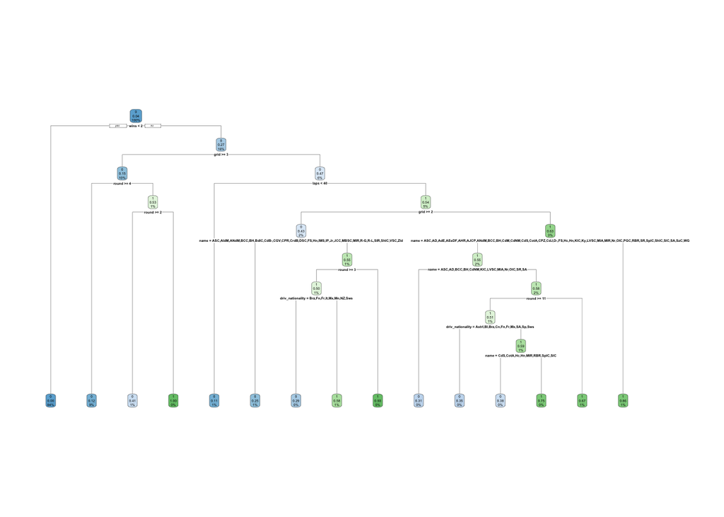

```r
rpart.plot(df.dt,faclen = 2)
```

#### RANDOM FOREST

```r
df.rf <- randomForest(winner ~ . -number -points -positionOrder -resultId -const_name -name -fullname -status, data = df.train, ntree = 200)
prediction.rf <- predict(df.rf, df.test, type = 'prob')
prediction.rf[is.na(prediction.rf)] <- 0
score_classification(df.test, prediction.rf)
```

```
## [1] 0.6059113
```

#### SVM classifier

```r
df.lsvm = svm(winner ~ ., data = df.train[, -c(5,6,8,9,12,13,15,17)], kernel = 'linear', fitted = FALSE, probability = TRUE)   #sigmoid kernel working best
prediction_svm <- predict(df.lsvm, newdata = df.test[,-c(5,6,8,9,12,13,15,17)], fitted = FALSE, probability = TRUE)
SVM_class = data.frame(attributes(prediction_svm)$probabilities)
score_classification(df.test, SVM_class)
```

```
## [1] 0.635468
```

### Visualize final prediction results

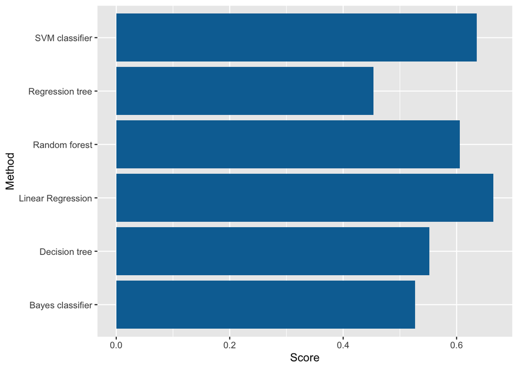

```r
accuracy_results = data.frame(c(score_regression(df.test, predict_lm), score_regression(df.test, predict_rt), score_classification(df.test, prediction_nb), score_classification(df.test, prediction_dt), score_classification(df.test, prediction.rf), score_classification(df.test, SVM_class)),c('Linear Regression', 'Regression tree','Bayes classifier','Decision tree','Random forest','SVM classifier'))
colnames(accuracy_results) = c('score', 'method')

ggplot(accuracy_results, aes(x = score, y = method)) +
  labs(x = 'Score', y = 'Method') +
  geom_bar(stat = "identity") +
  geom_col(fill = "#076fa2")
```

# CONCLUSIONS

Our initial goal wasn’t to analyze deeply the data that characterize a Formula 1 Race. Our goal was to rather try to predict the winner of a Race with the least possible number of numerical and categorical features.  
If we look at the last chart with all the accuracy score computed from both regression and classification models, we can see quite good results: all of the models predicted with a accuracy of about 60%, apart from regression tree and Bayes classifier. The first model is maybe too weak for such a big dataset like this one and for the second the explanation could be similar: the Bayes classifier works like a benchmark for other classifiers, so it is only an indicator of performance and maybe it is too weak too.